# Social Determinants of Students in New York City Schools and Effects on Specialized High School Admissions

## Conclusion

The widening racial and wealth disparity in the United States gives cause for concern. We can observe this trend firsthand in our analysis into the social determinants of NYC schools and the role they play in specialized high school admissions. There is no single solution to inequality in our society. Narrowing the racial and wealth gap requires intervention at the governmental and policy level. With the exponential increase in data collection over the past few decades, we can employ data science to help us target where capital, and human capital, can benefit society the most.

## Appendix - Exploratory Data Analysis

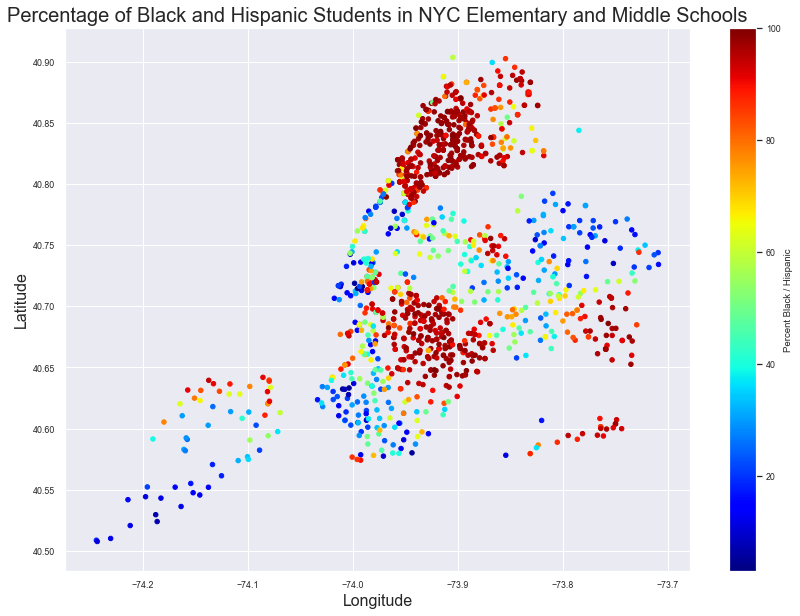

```python
fig, ax = plt.subplots(figsize=(14,10))
schools.plot(kind = 'scatter', x = 'Longitude', y = 'Latitude', c = 'Percent Black / Hispanic', colormap = 'jet', ax=ax) #colors based on racial makeup
plt.xlabel('Longitude',fontsize=16)
plt.ylabel('Latitude',fontsize=16)
plt.title('Percentage of Black and Hispanic Students in NYC Elementary and Middle Schools',fontsize=20)
```

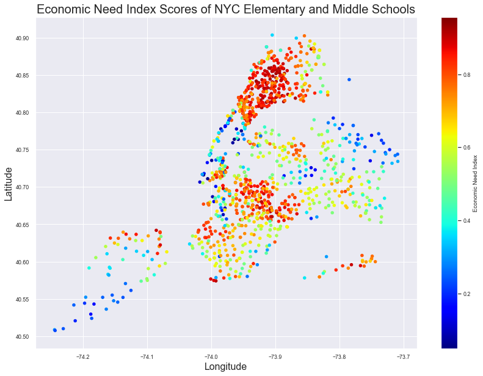

```python
fig, ax = plt.subplots(figsize=(14,10))

schools.plot(kind = 'scatter', x = 'Longitude', y = 'Latitude', c = 'Economic Need Index', colormap = 'jet', ax=ax) #colors based on racial makeup
plt.xlabel('Longitude',fontsize=16)
plt.ylabel('Latitude',fontsize=16)
plt.title('Economic Need Index Scores of NYC Elementary and Middle Schools',fontsize=20)
plt.figure(figsize=(14, 10))
```